# Mixed Model Demo

Rosie

2023-07-18

## Mixed Models

Some material adapted from: https://ourcodingclub.github.io/tutorials/mixed-models/#six

As we discussed in the powerpoint, mixed models are linear models where some of the factors are “fixed” or “explanatory” variables that you want to study. Are variables are known as “random” or “grouping” variables that you need to account for, but you don’t really care about them.

Additionally, the data for our random effect is just a sample of all the possibilities: with unlimited time and funding we might have sampled every cage possible, every school in the country, every chocolate in the box), but we usually tend to generalise results to a whole population based on representative sampling. We don’t care about estimating how much better pupils in school A have done compared to pupils in school B, but we know that their respective teachers might be a reason why their scores would be different, and we’d like to know how much variation is attributable to this when we predict scores for pupils in school Z. For the fish, we don’t really care whether cage 1 is better than cage 2, but we need to know what the cage effect is.

Let’s try this out with data on smelt cages.

Our study questions: * Does site impact fish growth? * Does season impact fish growth?

```r
cagedata = read_csv("SmeltCageData.csv")
str(cagedata)
```

```
## spc_tbl_ [1,162 × 9] (S3: spec_tbl_df/tbl_df/tbl/data.frame)
##  $ Deployment: chr [1:1162] "Winter" "Winter" "Winter" "Winter" ...
##  $ Period    : chr [1:1162] "Post" "Post" "Post" "Post" ...
##  $ Site      : chr [1:1162] "DWSC" "DWSC" "DWSC" "DWSC" ...
##  $ ID        : chr [1:1162] "Winter_122" "Winter_123" "Winter_124" "Winter_125" ...
##  $ FL_cm     : num [1:1162] 6.2 6.1 6 6 6.6 6.9 6.2 6.2 6.5 6.4 ...
##  $ Weight_g  : num [1:1162] 1.2 1.01 1.44 0.91 1.8 1.86 1.37 1.48 1.33 1.32 ...
##  $ Cage      : chr [1:1162] "B" "B" "B" "B" ...
##  $ K         : num [1:1162] 0.504 0.445 0.667 0.421 0.626 0.566 0.575 0.621 0.484 0.504 ...
##  $ CageRep   : chr [1:1162] "Winter_DWSC_B" "Winter_DWSC_B" "Winter_DWSC_B" "Winter_DWSC_B" ...
##  - attr(*, "spec")=
##   .. cols(
##   ..   Deployment = col_character(),
##   ..   Period = col_character(),
##   ..   Site = col_character(),
##   ..   ID = col_character(),
##   ..   FL_cm = col_double(),
##   ..   Weight_g = col_double(),
##   ..   Cage = col_character(),
##   ..   K = col_double(),
##   ..   CageRep = col_character()
##   .. )
##  - attr(*, "problems")=<externalptr>
```

```r
#Let's take a look at some of these variables
table(cagedata$Deployment, cagedata$Cage)
```

```
##
##            A   B  B3  B4  B5   C Cage A Cage B Cage C   D
##   Fall   162 167  30  30  30 159      0      0      0   0
##   Summer   0   0  29  30  29   0     39     39     48   0
##   Winter   0 124   0   0   0 122      0      0      0 124
```

```r
table(cagedata$Deployment, cagedata$Site)
```

```
##
##          DWSC FCCL  RV  SM Yolo
##   Fall      0   90 161 166  161
##   Summer    0   88 126   0    0
##   Winter  178    0 192   0    0
```

```r
table(cagedata$Deployment, cagedata$CageRep)
```

```
##
##          Fall_FCCL_B3 Fall_FCCL_B4 Fall_FCCL_B5 Fall_RV_A Fall_RV_B Fall_RV_C
##   Fall             30           30           30        54        54        53
##   Summer            0            0            0         0         0         0
##   Winter            0            0            0         0         0         0
##
##          Fall_SM_A Fall_SM_B Fall_SM_C Fall_Yolo_A Fall_Yolo_B Fall_Yolo_C
##   Fall          56        58        52          52          55          54
##   Summer         0         0         0           0           0           0
##   Winter         0         0         0           0           0           0
##
##          Summer_FCCL_B3 Summer_FCCL_B4 Summer_FCCL_B5 Summer_RV_Cage A
##   Fall                0              0              0                0
##   Summer             29             30             29               39
##   Winter              0              0              0                0
##
##          Summer_RV_Cage B Summer_RV_Cage C Winter_DWSC_B Winter_DWSC_C
##   Fall                  0                0             0             0
##   Summer               39               48             0             0
##   Winter                0                0            60            58
##
##          Winter_DWSC_D Winter_RV_B Winter_RV_C Winter_RV_D
##   Fall               0           0           0           0
##   Summer             0           0           0           0
##   Winter            60          64          64          64
```

```r
table(cagedata$Site, cagedata$Cage)
```

```
##
##          A   B  B3  B4  B5   C Cage A Cage B Cage C   D
##   DWSC   0  60   0   0   0  58      0      0      0  60
##   FCCL   0   0  59  60  59   0      0      0      0   0
##   RV    54 118   0   0   0 117     39     39     48  64
##   SM    56  58   0   0   0  52      0      0      0   0
##   Yolo  52  55   0   0   0  54      0      0      0   0
```

Site is crossed with Season. Rio Vista is still Rio Vista whether it is winter or summer.

This is obviously an unbalanced design, and it’s going to be pretty hard to tease anything apart, but we’re going to give it a try.

### Data exploration

Before we can model anything, we need to see what the data look like and assess whether we need any transformations.

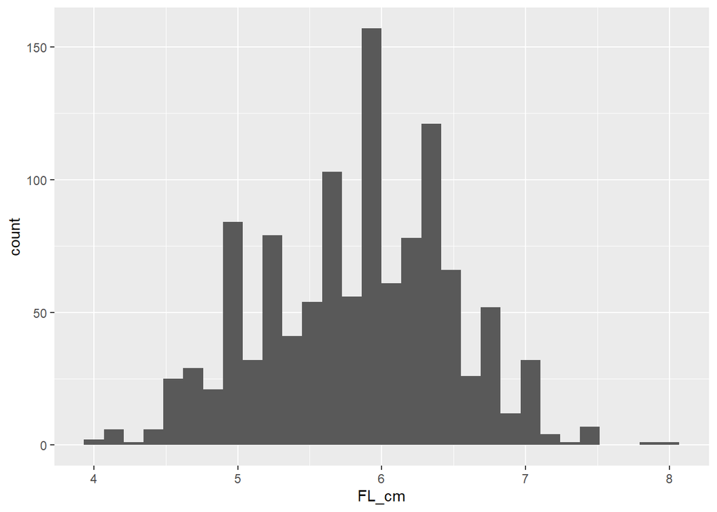

```r
#histogram of forklength
ggplot(cagedata, aes(x = FL_cm)) + geom_histogram()
```

```r
#remarkably normal
```

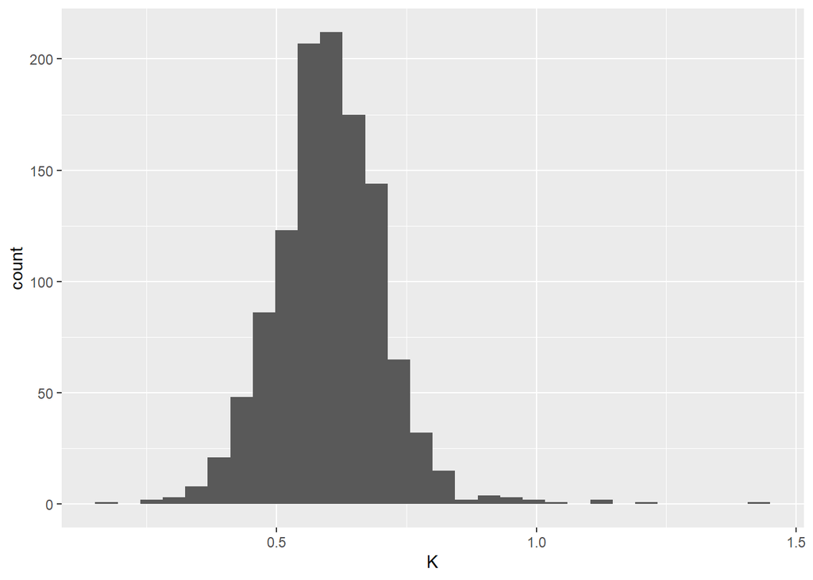

```r
#histogram of condition factor
ggplot(cagedata, aes(x = K)) + geom_histogram()
```

```r
#also looks ggood
```

I like seeing whether I can pick out trends in the raw data that I can model before I get started.

- Does site and/or season impact fish growth?

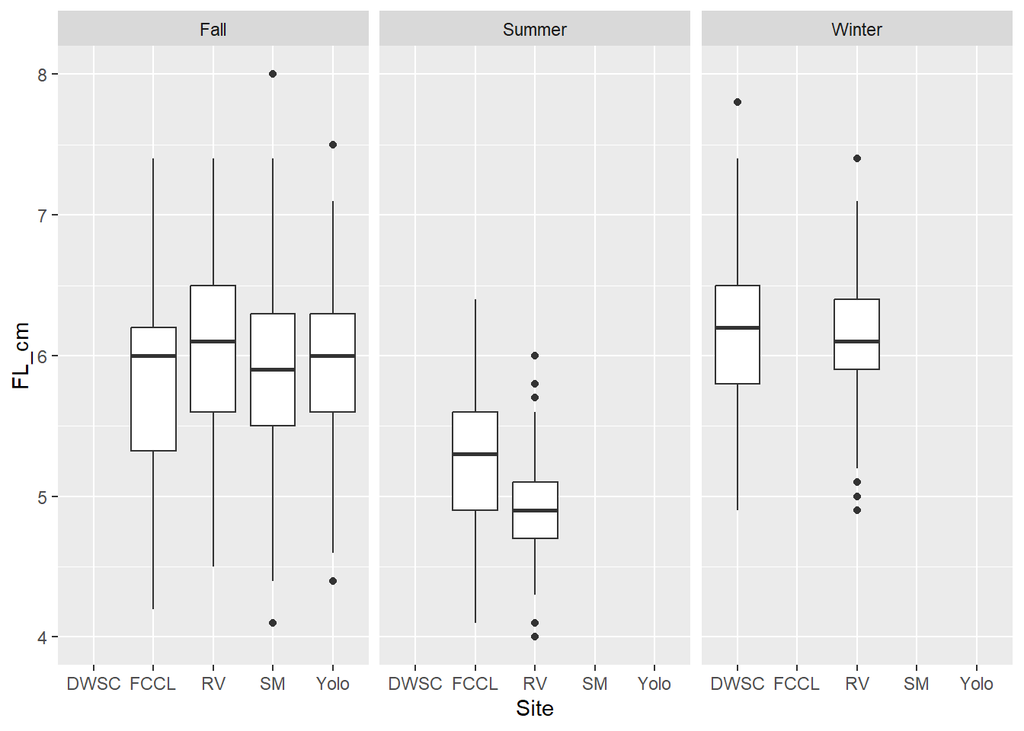

```r
ggplot(cagedata, aes(x = Site, y = FL_cm)) + geom_boxplot()+
  facet_wrap(~Deployment)
```

But how do we show this statistically?

We know fish within a cage are not independent replicates, so we could just average the length within each cage

```r
avesmelt = group_by(cagedata, Site, Deployment, Cage) %>%
  summarize(FL = mean(FL_cm, na.rm =T))
lm1 = lm(FL ~ Site + Deployment, data = avesmelt)
summary(lm1)
```

```
##
## Call:
## lm(formula = FL ~ Site + Deployment, data = avesmelt)
##
## Residuals:
##       Min        1Q    Median        3Q       Max
## -0.297099 -0.055674  0.008967  0.070923  0.259165
##
## Coefficients:
##                   Estimate Std. Error t value Pr(>|t|)
## (Intercept)       5.956921   0.138702  42.948  < 2e-16 ***
## SiteFCCL          0.006845   0.144870   0.047   0.9629
## SiteRV           -0.053123   0.118286  -0.449   0.6590
## SiteSM           -0.070752   0.161969  -0.437   0.6677
## SiteYolo         -0.047196   0.161969  -0.291   0.7743
## DeploymentSummer -0.855155   0.083641 -10.224 1.12e-08 ***
## DeploymentWinter  0.212869   0.110646   1.924   0.0713 .
## ---
## Signif. codes:  0 '***' 0.001 '**' 0.01 '*' 0.05 '.' 0.1 ' ' 1
##
## Residual standard error: 0.1449 on 17 degrees of freedom
## Multiple R-squared:  0.9177, Adjusted R-squared:  0.8886
## F-statistic: 31.59 on 6 and 17 DF,  p-value: 2.588e-08
```

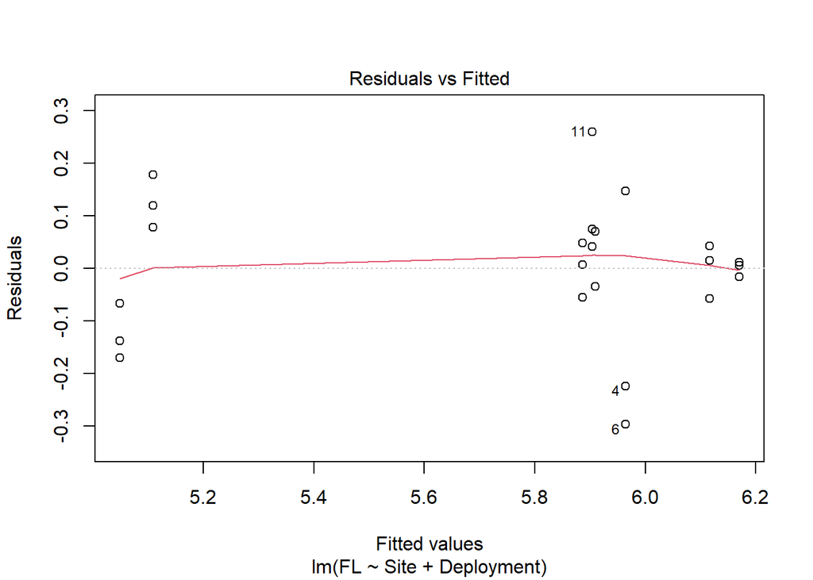

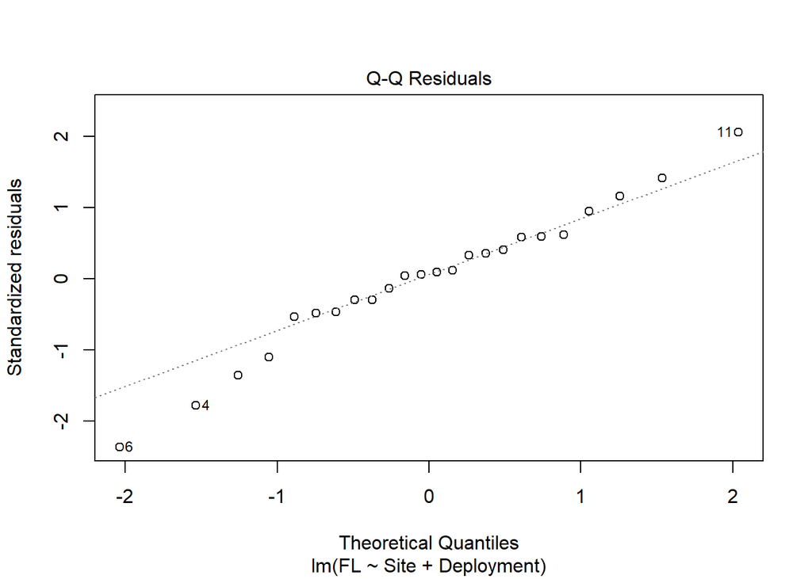

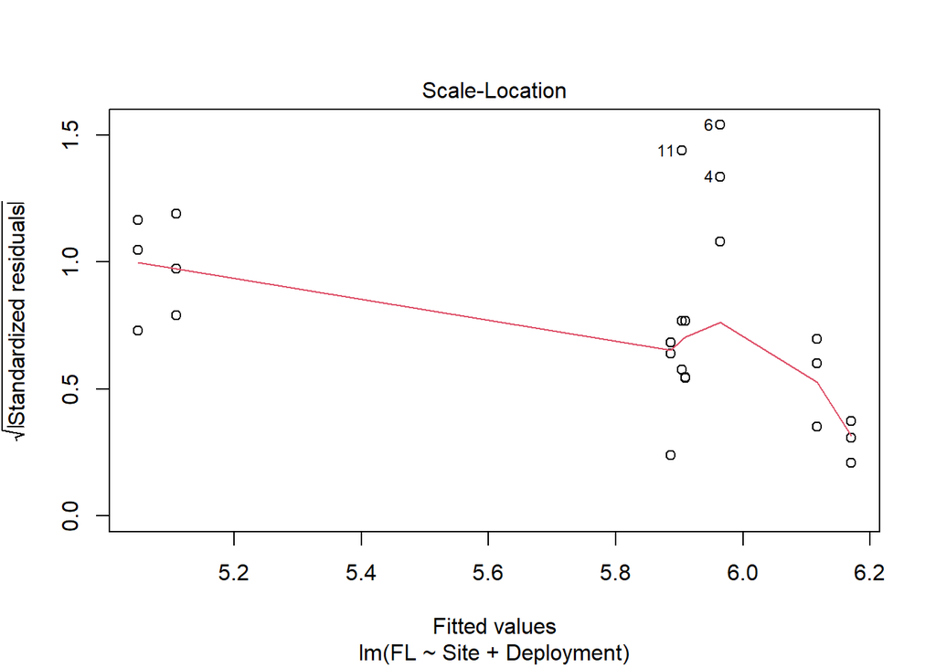

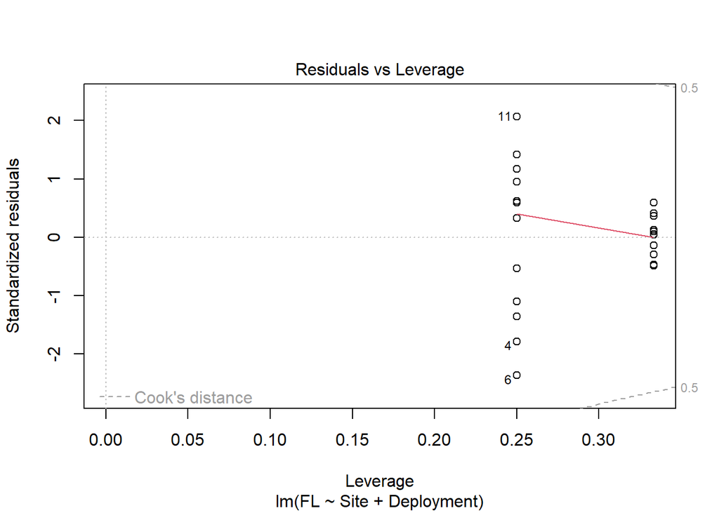

```r
plot(lm1)
```

However, when we average all the values of fish within a cage, we lose a lot of information, which is a shame.

A better way, would be to include a random effect of cage (nested within site).

```r
m1 = lmer(FL_cm ~ Site + Deployment + (1|Site/Cage), data = cagedata)
summary(m1)
```

```
## Linear mixed model fit by REML. t-tests use Satterthwaite's method [
## lmerModLmerTest]
## Formula: FL_cm ~ Site + Deployment + (1 | Site/Cage)
##    Data: cagedata
##
## REML criterion at convergence: 1863.3
##
## Scaled residuals:
##     Min      1Q  Median      3Q     Max
## -3.4031 -0.6274  0.0352  0.6226  3.9207
##
## Random effects:
##  Groups    Name        Variance Std.Dev.
##  Cage:Site (Intercept) 0.006519 0.08074
##  Site      (Intercept) 0.052714 0.22960
##  Residual              0.283572 0.53251
## Number of obs: 1158, groups:  Cage:Site, 19; Site, 5
##
## Fixed effects:
##                    Estimate Std. Error         df t value Pr(>|t|)
## (Intercept)       6.023e+00  2.453e-01  1.500e-08  24.554   1.0000
## SiteFCCL         -7.512e-02  3.415e-01  1.408e-08  -0.220   1.0000
## SiteRV           -1.155e-01  3.353e-01  1.309e-08  -0.344   1.0000
## SiteSM           -1.379e-01  3.417e-01  1.412e-08  -0.404   1.0000
## SiteYolo         -1.134e-01  3.418e-01  1.413e-08  -0.332   1.0000
## DeploymentSummer -8.277e-01  5.979e-02  4.290e+01 -13.842   <2e-16 ***
## DeploymentWinter  1.465e-01  6.076e-02  1.348e+02   2.410   0.0173 *
## ---
## Signif. codes:  0 '***' 0.001 '**' 0.01 '*' 0.05 '.' 0.1 ' ' 1
##
## Correlation of Fixed Effects:
##             (Intr) StFCCL SiteRV SiteSM SiteYl DplymS
## SiteFCCL    -0.713
## SiteRV      -0.712  0.514
## SiteSM      -0.718  0.512  0.511
## SiteYolo    -0.718  0.512  0.511  0.515
## DplymntSmmr -0.064 -0.041 -0.033  0.046  0.046
## DplymntWntr -0.248  0.156  0.103  0.178  0.178  0.258
```

Comparing the outputs from the two models, the fixed effects of the mixed model looks a lot like the effects of the model with the averages within each cage, however the mixed model also gives us information about the random effects, which is helpful in understanding our data and planing for future studies.

The output from the linear model tells us the significant difference between the intercept (DWSC and Fall) versus teh other levels of the factor. If we want to know all the pairwise comparisons, we need to do a post-hoc. The `emmeans` package has ways of doing a bunch of different post-hocs.

```r
library(emmeans)

#first let's look at the regular linear model

emmeans(lm1, pairwise ~ Deployment)
```

```
## $emmeans
##  Deployment emmean     SE df lower.CL upper.CL
##  Fall         5.92 0.0495 17     5.82     6.03
##  Summer       5.07 0.0724 17     4.92     5.22
##  Winter       6.14 0.0836 17     5.96     6.31
##
## Results are averaged over the levels of: Site
## Confidence level used: 0.95
##
## $contrasts
##  contrast        estimate     SE df t.ratio p.value
##  Fall - Summer      0.855 0.0836 17  10.224  <.0001
##  Fall - Winter     -0.213 0.1106 17  -1.924  0.1624
##  Summer - Winter   -1.068 0.1106 17  -9.653  <.0001
##
## Results are averaged over the levels of: Site
## P value adjustment: tukey method for comparing a family of 3 estimates
```

```r
emmeans(lm1, pairwise ~ Site)
```

```
## $emmeans
##  Site emmean     SE df lower.CL upper.CL
##  DWSC   5.74 0.1080 17     5.52     5.97
##  FCCL   5.75 0.0683 17     5.61     5.89
##  RV     5.69 0.0483 17     5.59     5.79
##  SM     5.67 0.0996 17     5.46     5.88
##  Yolo   5.70 0.0996 17     5.49     5.91
##
## Results are averaged over the levels of: Deployment
## Confidence level used: 0.95
##
## $contrasts
##  contrast    estimate     SE df t.ratio p.value
##  DWSC - FCCL -0.00684 0.1449 17  -0.047  1.0000
##  DWSC - RV    0.05312 0.1183 17   0.449  0.9908
##  DWSC - SM    0.07075 0.1620 17   0.437  0.9917
##  DWSC - Yolo  0.04720 0.1620 17   0.291  0.9983
##  FCCL - RV    0.05997 0.0836 17   0.717  0.9497
##  FCCL - SM    0.07760 0.1106 17   0.701  0.9534
##  FCCL - Yolo  0.05404 0.1106 17   0.488  0.9874
##  RV - SM      0.01763 0.1106 17   0.159  0.9998
##  RV - Yolo   -0.00593 0.1106 17  -0.054  1.0000
##  SM - Yolo   -0.02356 0.1183 17  -0.199  0.9996
##
## Results are averaged over the levels of: Deployment
## P value adjustment: tukey method for comparing a family of 5 estimates
```

Now let’s look at the mixed model.

```r
emmeans(m1, pairwise ~ Deployment)
```

```
## $emmeans
##  Deployment emmean    SE   df lower.CL upper.CL
##  Fall         5.93 0.108 3204     5.72     6.15
##  Summer       5.11 0.117  834     4.88     5.34
##  Winter       6.08 0.115 1449     5.86     6.31
##
## Results are averaged over the levels of: Site
## Degrees-of-freedom method: kenward-roger
## Confidence level used: 0.95
##
## $contrasts
##  contrast        estimate     SE    df t.ratio p.value
##  Fall - Summer      0.828 0.0615  92.8  13.462  <.0001
##  Fall - Winter     -0.146 0.0621 265.7  -2.358  0.0498
##  Summer - Winter   -0.974 0.0760  52.9 -12.814  <.0001
##
## Results are averaged over the levels of: Site
## Degrees-of-freedom method: kenward-roger
## P value adjustment: tukey method for comparing a family of 3 estimates
```

```r
emmeans(m1, pairwise ~ Site)
```

```
## $emmeans
##  Site emmean    SE    df lower.CL upper.CL
##  DWSC   5.80 0.241  2268     5.32     6.27
##  FCCL   5.72 0.239  2717     5.25     6.19
##  RV     5.68 0.233 13533     5.22     6.14
##  SM     5.66 0.240  2761     5.19     6.13
##  Yolo   5.68 0.240  2768     5.21     6.15
##
## Results are averaged over the levels of: Deployment
## Degrees-of-freedom method: kenward-roger
## Confidence level used: 0.95
##
## $contrasts
##  contrast    estimate    SE   df t.ratio p.value
##  DWSC - FCCL  0.07512 0.342 2211   0.220  0.9995
##  DWSC - RV    0.11549 0.336 4047   0.344  0.9970
##  DWSC - SM    0.13791 0.342 2553   0.403  0.9944
##  DWSC - Yolo  0.11344 0.342 2556   0.332  0.9974
##  FCCL - RV    0.04037 0.334 5361   0.121  1.0000
##  FCCL - SM    0.06278 0.338 2709   0.186  0.9997
##  FCCL - Yolo  0.03831 0.338 2712   0.113  1.0000
##  RV - SM      0.02241 0.335 4965   0.067  1.0000
##  RV - Yolo   -0.00206 0.335 4971  -0.006  1.0000
##  SM - Yolo   -0.02447 0.337 2907  -0.073  1.0000
##
## Results are averaged over the levels of: Deployment
## Degrees-of-freedom method: kenward-roger
## P value adjustment: tukey method for comparing a family of 5 estimates
```

They look pretty darn similar. However, we can use the variance of the random effects from the origional model output to plan our study design for next time.

## Sampling design

When you are conducting an experiment, like fish in cages, your fixed and random effects are included in your study design. However, when you are dealing with samples from the environment, you might have to make some choices about which variables to treat as fixed and which to treat as random.

If you haven’t already downloaded the data, grab it here: https://filelib.wildlife.ca.gov/Public/TownetFallMidwaterTrawl/FMWT%20Data/FMWT%201967-2022%20Catch%20Matrix_updated.zip

```r
FMWT = read_csv("FMWT 1967-2022 Catch Matrix_updated.csv")
FMWT90 = filter(FMWT, Year>1999, Year <2011)

str(FMWT90)
```

[output not shown]

[output cut: 192 more lines]

```
##   ..   Wakasagi = col_double(),
##   ..   `Walleye Surfperch` = col_double(),
##   ..   Warmouth = col_double(),
##   ..   `Western Mosquitofish` = col_double(),
##   ..   `White Catfish` = col_double(),
##   ..   `White Crappie` = col_double(),
##   ..   `White Croaker` = col_double(),
##   ..   `White Sea Bass` = col_double(),
##   ..   `White Seaperch` = col_double(),
##   ..   `White Sturgeon` = col_double(),
##   ..   `Whitebait Smelt` = col_double(),
##   ..   `Wolf Eel` = col_double(),
##   ..   `Yellowfin Goby` = col_double()
##   .. )
##  - attr(*, "problems")=<externalptr>
```

```r
#A few minor changes to make the data more user-friendly

FMWT90 = mutate(FMWT90, StationCode = as.factor(StationCode), TideCode = as.factor(TideCode), index = as.logical(index),
                TotalCatch = rowSums(across(`American Shad`:`Yellowfin Goby`), na.rm =T)) %>%
  select(Year, SampleDate, SurveyNumber, StationCode, index, StationLat, StationLong, DepthBottom, WaterTemperature,
         ConductivityTop, Turbidity, Secchi, TideCode, Microcystis, TotalCatch)
```

As always, we want to start by looking at our data.

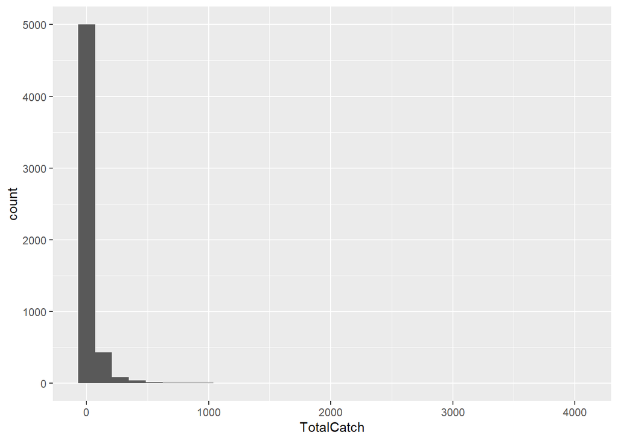

```r
ggplot(FMWT90, aes(x = TotalCatch)) + geom_histogram()
```

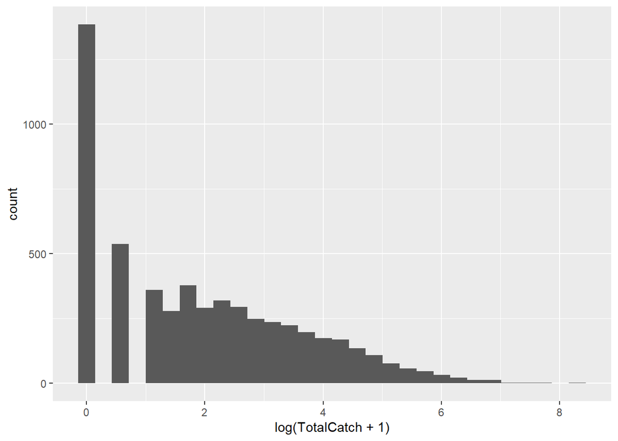

```r
ggplot(FMWT90, aes(x = log(TotalCatch +1)))+ geom_histogram()
```

This data is a little zero inflated, so we probably want to use some kind of fancy model to do it right, but for the sake of the example, we’ll go with it for now. We’ll definitely want to log-transform it though.

The problem comes when we want to decide which factors are likely to be fixed and which are likely to be random. That is going to be based on our question. We’ll start with

“How does secchi depth impact fish catch”.

I like to start with a quick graph.

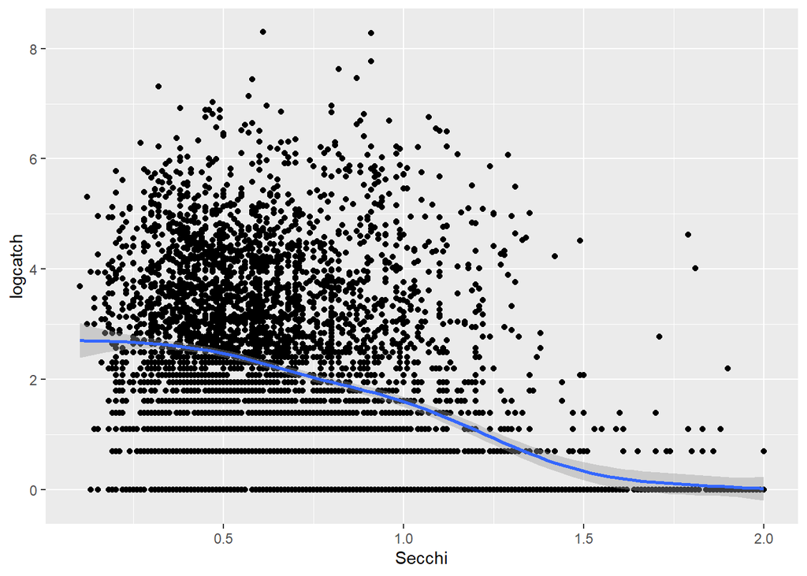

```r
FMWT90 = mutate(FMWT90, logcatch = log(TotalCatch+1))


ggplot(FMWT90, aes(x = Secchi, y = logcatch))+ geom_point()+ geom_smooth()
```

It looks like there is definitely a trend there.

However, there are a lot of other factors that probably affect fish abundance too. We should account for them.

- Year
- Time of year
- Depth of water
- Region of the estuary
- Station
- amount of water sampled
- other environmental factors

Some of these factors we might want to include as explanatory variables (fixed effects), whereas other we might want to include as grouping variables (random effects).

We are unlikely to be interested in the impact of station on it’s own, so let’s definitely put that in the random effects.

```r
m1 = lmer(logcatch ~ Secchi + Year + SurveyNumber + (1|StationCode), data = FMWT90)

summary(m1)
```

```
## Linear mixed model fit by REML. t-tests use Satterthwaite's method [
## lmerModLmerTest]
## Formula: logcatch ~ Secchi + Year + SurveyNumber + (1 | StationCode)
##    Data: FMWT90
##
## REML criterion at convergence: 19145
##
## Scaled residuals:
##     Min      1Q  Median      3Q     Max
## -2.9586 -0.6809 -0.0611  0.6316  3.9458
##
## Random effects:
##  Groups      Name        Variance Std.Dev.
##  StationCode (Intercept) 0.5257   0.725
##  Residual                1.7364   1.318
## Number of obs: 5547, groups:  StationCode, 122
##
## Fixed effects:
##                Estimate Std. Error         df t value Pr(>|t|)
## (Intercept)   1.531e+02  1.246e+01  5.543e+03   12.29   <2e-16 ***
## Secchi       -1.332e+00  6.705e-02  4.690e+03  -19.87   <2e-16 ***
## Year         -7.425e-02  6.218e-03  5.543e+03  -11.94   <2e-16 ***
## SurveyNumber -2.572e-01  1.232e-02  5.417e+03  -20.86   <2e-16 ***
## ---
## Signif. codes:  0 '***' 0.001 '**' 0.01 '*' 0.05 '.' 0.1 ' ' 1
##
## Correlation of Fixed Effects:
##             (Intr) Secchi Year
## Secchi       0.424
## Year        -1.000 -0.428
## SurveyNumbr -0.238  0.027  0.233
```

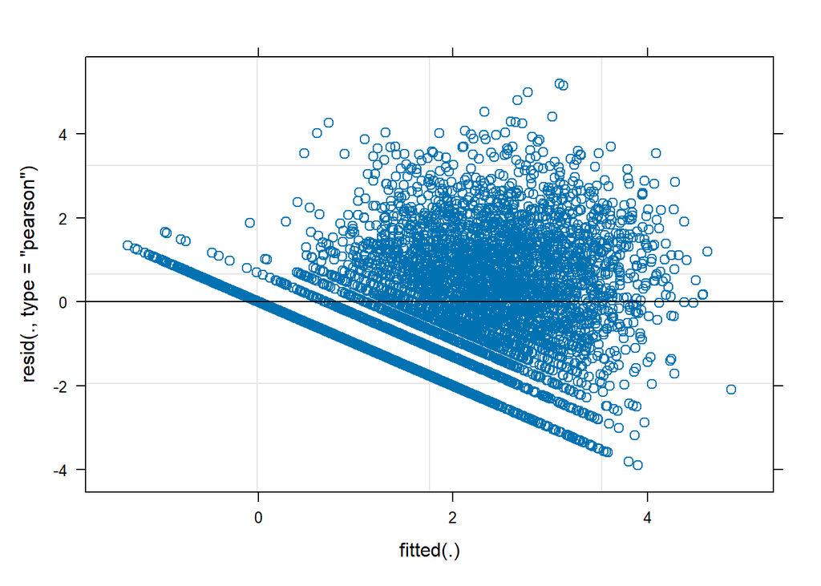

```r
plot(m1)
```

But maybe we aren’t really interested in changes over time. Let’s put year and time of year (survey code) as random effects too.

```r
m2 = lmer(logcatch ~ Secchi + (1|Year)+ (1|SurveyNumber)+ (1|StationCode), data = FMWT90)

summary(m2)
```

```
## Linear mixed model fit by REML. t-tests use Satterthwaite's method [
## lmerModLmerTest]
## Formula:
## logcatch ~ Secchi + (1 | Year) + (1 | SurveyNumber) + (1 | StationCode)
##    Data: FMWT90
##
## REML criterion at convergence: 18917.2
##
## Scaled residuals:
##     Min      1Q  Median      3Q     Max
## -3.2398 -0.6737 -0.0559  0.6141  4.0259
##
## Random effects:
##  Groups       Name        Variance Std.Dev.
##  StationCode  (Intercept) 0.5283   0.7269
##  Year         (Intercept) 0.1685   0.4105
##  SurveyNumber (Intercept) 0.3656   0.6046
##  Residual                 1.6486   1.2840
## Number of obs: 5547, groups:  StationCode, 122; Year, 11; SurveyNumber, 7
##
## Fixed effects:
##               Estimate Std. Error         df t value Pr(>|t|)
## (Intercept)    2.60017    0.27479   11.38352   9.462 9.82e-07 ***
## Secchi        -1.23181    0.06997 4470.55970 -17.605  < 2e-16 ***
## ---
## Signif. codes:  0 '***' 0.001 '**' 0.01 '*' 0.05 '.' 0.1 ' ' 1
##
## Correlation of Fixed Effects:
##        (Intr)
## Secchi -0.186
```

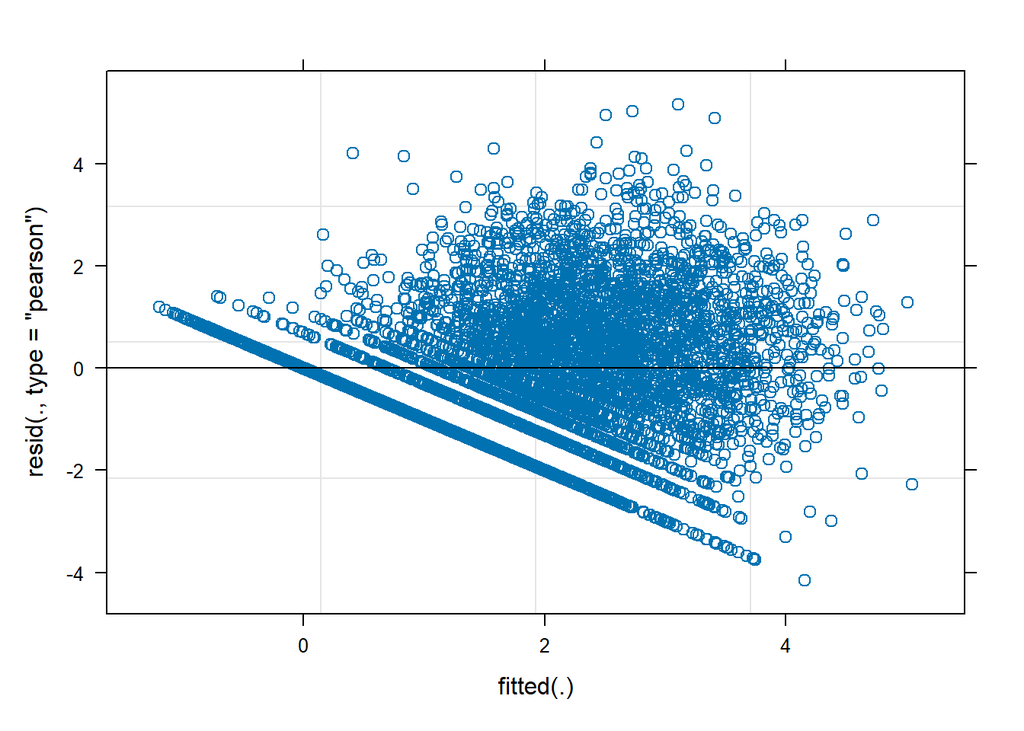

```r
plot(m2)
```

Let’s compare these two models.

```r
anova(m1, m2)
```

```
## refitting model(s) with ML (instead of REML)
```

```
## Data: FMWT90
## Models:
## m1: logcatch ~ Secchi + Year + SurveyNumber + (1 | StationCode)
## m2: logcatch ~ Secchi + (1 | Year) + (1 | SurveyNumber) + (1 | StationCode)
##    npar   AIC   BIC  logLik deviance  Chisq Df Pr(>Chisq)
## m1    6 19134 19174 -9561.2    19122
## m2    6 18925 18965 -9456.4    18913 209.41  0
```

The model with fewer fixed effects has a greater log-likelihood and lower BIC (BIC is better than AIC for mixed models). So, if we are trying to choose between including something as a fixed or random effect, and we aren’t super interested in it’s effects, going with random effects will give you a better model.

### Further Reading

https://en.wikipedia.org/wiki/Mixed_model

Greven, S., and T. Kneib. 2010. On the behaviour of marginal and conditional AIC in linear mixed models. Biometrika 97:773-789. 10.1093/biomet/asq042

Zuur AF, Ieno EN, Walker NJ, Saveliev AA, Smith GM. 2009. Mixed Effects Models and Extensions in Ecology with R. New York, NY: Springer.

https://ourcodingclub.github.io/tutorials/mixed-models/#six

https://cran.r-project.org/web/views/MixedModels.html

https://cran.r-project.org/web/packages/lme4/vignettes/lmer.pdf